# My Website

Joshua Soll

Last Updated: 2024-12-02

# *Select the tabs below to see my work*

## *Purpose*

### *GIS Final Project*

The purpose of this website is to demonstrate my skills in creating a website via R markdown and display some code and data that I am using for my master’s thesis.

### *Glider Data*

This oceanographic data may provide insight into the preferences and habits of the whale species I am studying for my thesis, and the map created using this data will support my thesis development.

## *Data*

### *Data Collection*

The glider’s southern mission, having a 23 day duration, started in La Parguera, Puerto Rico, and was completed towards the east end of St. Thomas. The glider’s northern mission, having a 20 day duration, started off the shelf north of St. Thomas and was completed in Aguadilla Bay, Aguadilla, Puerto Rico.

As the glider travels, it follows a series of waypoints and dives to depths specified by the the pilot and collects sensor data. This glider, named UVI1, is equipped with pressure, oxygen, CTD sensors, and has a hydrophone for cetacean detection.

This data collected during these missions consists of scientific sensor data that the glider transmitted via satellite during surfacing events. Not all data could be sent during this time, so values are missing. However, these two datasets are a good start in painting a picture of oceanographic conditions in the region. Through my research aimed at detecting and identifying whale noises, I can use this data to determine the depth at which whales were detected, and the conditions in which the whales were detected, which may provide insight into the preferences and habits of these animals.

### *Data Description*

The data are separated by mission – the north side deployment file name base is UVI_PR_W_Northside_1, and the south side deployment file name base is UVI_PR_E_Southside_1. Each deployment starts with raw real time data. The raw real time data is glider sensor data that was transmitted during the glider’s surfacing events in mission.

Below is the head of the raw UVI1_PR_E_Southside_1 data. We’ll be using this dataset as the example for the rest of the process.

```r
# 1. Loading the data here
df <- read.csv('/Users/JoshSoll/Desktop/Glider_Lab/Glider_Data/UVI1_ScienceData_PR_E_Southside_1.csv')

head(df)
```

```
##       depth latitude longitude                 time temperature conductivity
## 1  5.082533 17.85069 -67.05247 2024-08-28T13:39:24Z     30.1045      5.87501
## 2  8.121038 17.85067 -67.05243 2024-08-28T13:39:45Z     30.0901      5.87476
## 3 12.475897 17.85066 -67.05239 2024-08-28T13:40:06Z     30.0832      5.87483
## 4        NA 17.85064 -67.05236 2024-08-28T13:40:25Z          NA           NA
## 5 17.663874 17.85064 -67.05236 2024-08-28T13:40:27Z     30.0826      5.87762
## 6 22.334194 17.85063 -67.05232 2024-08-28T13:40:48Z     30.0691      5.88732
##    density oxygen_concentration oxygen_saturation pressure sound_speed
## 1 1021.854              186.662            96.136   5.1132    1545.837
## 2 1021.878              186.590            96.072   8.1701    1545.866
## 3 1021.902              186.613            96.051  12.5514    1545.930
## 4       NA                   NA                NA       NA          NA
## 5 1021.938              186.624            96.053  17.7710    1546.034
## 6 1022.018              186.689            96.071  22.4699    1546.162
```

As you can see, many NaNs exist in the data. Data exists for these NaN spaces, but the glider is only able to send a portion of its collected data during its limited surfacing events. The full sensor dataset is downloaded at the end of the mission and can only be decoded with a proprietary decoding shell packages that converts binary data to a readable format. At the moment I do not have access to the decoding packages, so I am using the real time data. This does provide the opportunity to do some manipulation.

## *Data Processing*

### *Adjust the Time Column*

The “time” column is currently in a format that combines date and time. I want to separate the data in this column so it can more easily be read by GIS.

Here I am displaying the head of the data with only these three columns selected to verify the code worked.

```r
# 2. Split the "time" column into separate "date" and "time_only" columns
df <- df %>%
  mutate(
    datetime = as.POSIXct(time, format = "%Y-%m-%dT%H:%M:%S"),  # Adjust format as needed
    date = as.Date(datetime),
    time_only = format(datetime, "%H:%M:%S")
  )

# Display the result to verify
head(df[, c("time", "date", "time_only")])
```

```
##                   time       date time_only
## 1 2024-08-28T13:39:24Z 2024-08-28  13:39:24
## 2 2024-08-28T13:39:45Z 2024-08-28  13:39:45
## 3 2024-08-28T13:40:06Z 2024-08-28  13:40:06
## 4 2024-08-28T13:40:25Z 2024-08-28  13:40:25
## 5 2024-08-28T13:40:27Z 2024-08-28  13:40:27
## 6 2024-08-28T13:40:48Z 2024-08-28  13:40:48
```

### *Interpolating Depth*

As previously mentioned, this raw, real time data is incomplete, including depth values that represent the glider’s depth in meters at the time of data collection. We do have a good amount of depth data, and given that the glider’s rates of descent and ascent are fairly consistent, we can interpolate the missing depth values using existing ones.

In this original dataset you can see that depth values are missing:

```r
head(df$depth, 10)
```

```
##  [1]  5.082533  8.121038 12.475897        NA 17.663874 22.334194        NA
##  [8] 27.517250        NA        NA
```

After running the interpolation code, you can see that the missing values have been interpolated.

```r
# 3. Interpolate missing values in the "depth" column
df <- df %>%
  mutate(depth = zoo::na.approx(depth, na.rm = FALSE))  # Linear interpolation for NA values

# Display the result to verify
head(df$depth, 10)
```

```
##  [1]  5.082533  8.121038 12.475897 15.069885 17.663874 22.334194 24.925722
##  [8] 27.517250 28.545387 29.573524
```

I want to verify that depths have been interpolated properly, so here I have plotted a time series of depth to see that depth values are conistent with what we sent the glider to in mission. I selected the timeseries for a specific day so that you can see the dives/climbs of the glider (called yo’s)

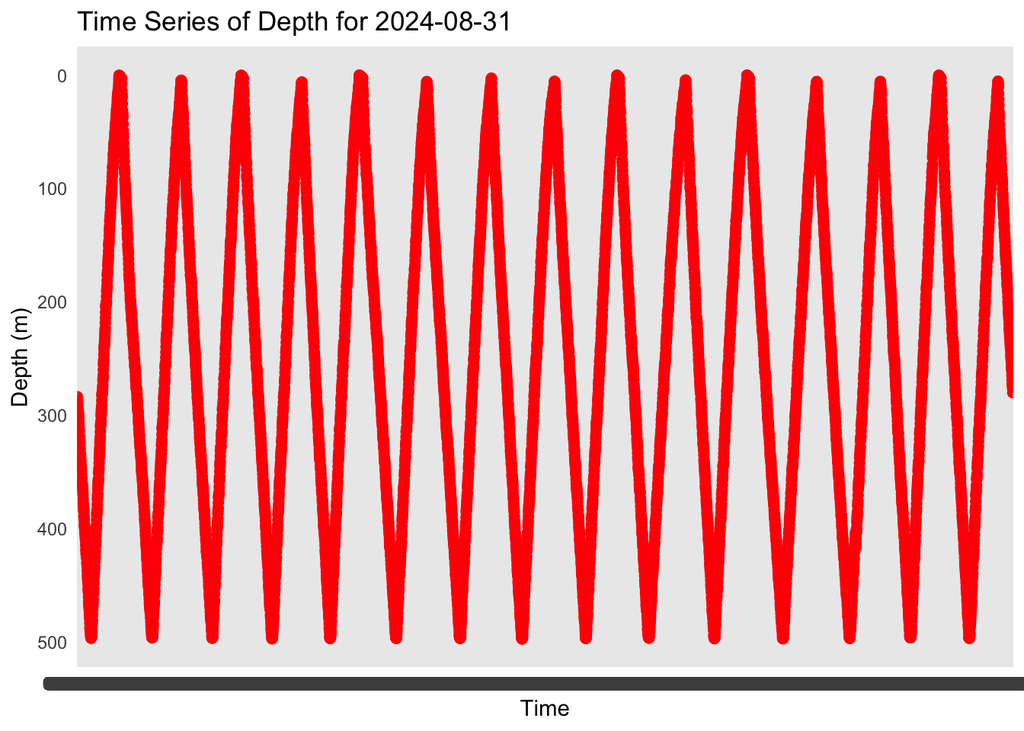

```r
# Specify the date you want to filter for
specific_date <- as.Date("2024-08-31")  # Replace with your desired date

# Filter data for the specific date
filtered_df <- df %>% filter(date == specific_date)

# Plot depth over time for the specific date
ggplot(filtered_df, aes(x = time_only, y = depth)) +
  geom_line(color = "blue", linewidth = 1) +  # Connect points with lines
  geom_point(color = "red", size = 2) + # Optional: Add points for clarity
  scale_y_reverse() +  # Invert y-axis
  labs(
    title = paste("Time Series of Depth for", specific_date),
    x = "Time",
    y = "Depth (m)"
  ) +
  theme_minimal()
```

Lastly, I want to make a new dataframe that averages all sensor values by daily time bins so that users of this map in GIS can select these points and see what the data in the area is like.

```r
# Ensure datetime is set as a proper column and create a date column
df <- df %>%
  mutate(
    datetime = as.POSIXct(time, format = "%Y-%m-%dT%H:%M:%S"),
    date = as.Date(datetime)  # Create a date column
  ) %>%
  arrange(datetime)

# Group by date and calculate daily averages, applying mean with na.rm = TRUE
daily_avg_df <- df %>%
  group_by(date) %>%  # Group by the date column
  summarize(across(where(is.numeric), ~ mean(.x, na.rm = TRUE)), .groups = "drop")  # Calculate mean for numeric columns

# Display the result to verify
head(daily_avg_df)
```

```
## # A tibble: 6 × 11
##   date       depth latitude longitude temperature conductivity density
##   <date>     <dbl>    <dbl>     <dbl>       <dbl>        <dbl>   <dbl>
## 1 2024-08-28  195.     17.8     -67.0        21.8         5.16   1026.
## 2 2024-08-29  246.     17.8     -66.9        19.9         4.96   1027.
## 3 2024-08-30  245.     17.7     -66.8        20.0         4.97   1027.
## 4 2024-08-31  246.     17.8     -66.7        20.0         4.97   1027.
## 5 2024-09-01  241.     17.7     -66.5        20.1         4.99   1027.
## 6 2024-09-02  248.     17.7     -66.3        19.9         4.96   1027.
## # ℹ 4 more variables: oxygen_concentration <dbl>, oxygen_saturation <dbl>,
## #   pressure <dbl>, sound_speed <dbl>
```

## *Map*

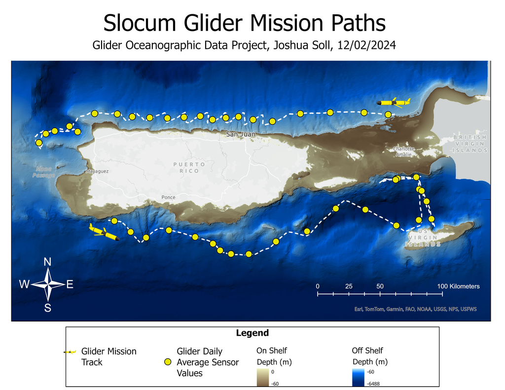

Above is a map of two glider mission paths from my deployments in the Fall of 2024. No whale detections were made as of yet, so the map only shows the glider tracks. Once I can finalize an online interactive map, you will be able to select each yellow point on the two tracks and see the average daily sensor values for the missions.